# Reproducible Research: Peer Assessment 1

Set working directory for assignment

```r
setwd("~/Desktop/RepData_PeerAssessment1")
```

## Loading and preprocessing the data

#### 1. Load data

The dataset for this assignment makes use of data from a personal activity monitoring device. Unzip the file and load the dataset.

```r
if (!exists("activity.csv")) {
    unzip("activity.zip")
}
data <- read.csv("activity.csv")

head(data)
```

```
##   steps       date interval
## 1    NA 2012-10-01        0
## 2    NA 2012-10-01        5
## 3    NA 2012-10-01       10
## 4    NA 2012-10-01       15
## 5    NA 2012-10-01       20
## 6    NA 2012-10-01       25
```

#### 2. Transforming data classes

To ensure efficiency, ensure that all columns are classed correctly.

```r
data$steps <- as.numeric(data$steps)
data$date <- as.Date(data$date, "%Y-%m-%d")
data$interval <- as.numeric(data$interval)

str(data)
```

```
## 'data.frame':    17568 obs. of  3 variables:
##  $ steps   : num  NA NA NA NA NA NA NA NA NA NA ...
##  $ date    : Date, format: "2012-10-01" "2012-10-01" ...
##  $ interval: num  0 5 10 15 20 25 30 35 40 45 ...
```

## What is mean total number of steps taken per day?

#### 1. Make a histogram of the total number of steps taken each day.

Get the total number of steps each day using aggregate(). Create a new dataset “DailySteps” then use this information to create a histogram using base package.

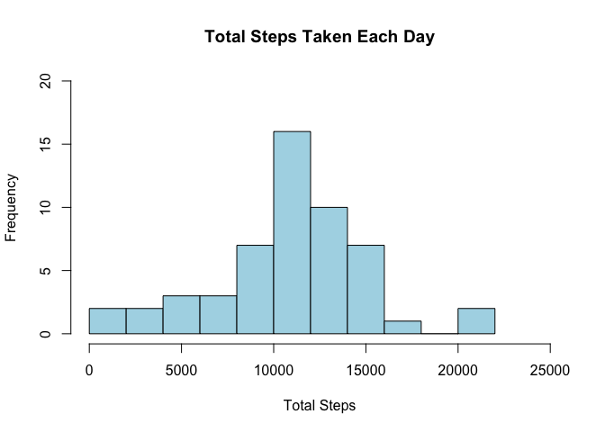

```r
DailySteps <- aggregate(steps ~ date, data, sum)
hist(DailySteps$steps, col = "lightblue", breaks = 15,
     xlab = "Total Steps",
     xlim = c(0, 25000), ylim = c(0, 20),
     main = "Total Steps Taken Each Day")
```

#### 2. Calculate and report the mean and median of the total number of steps taken per day.

Get the Mean and Median steps from the “DailySteps” data created above.

```r
mean(DailySteps$steps, na.rm = TRUE)
```

```
## [1] 10766.19
```

```r
median(DailySteps$steps, na.rm = TRUE)
```

```
## [1] 10765
```

## What is the average daily activity pattern?

To get the average daily activity patterns,create a new dataset called “AverageDailyActivity” using aggregate()

```r
AverageDailyActivity <- aggregate(steps ~ interval, data, mean)
```

#### 1. Make a time series plot

Create a plot of the 5 minute interval and the average number of steps taken using plot() from base package.

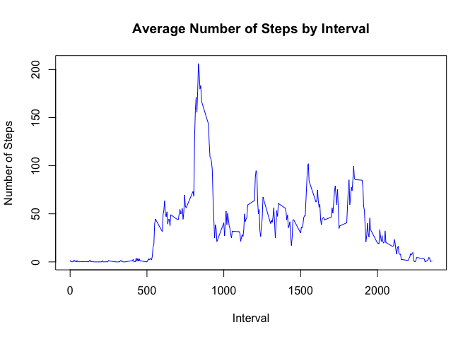

```r
plot(AverageDailyActivity$interval,AverageDailyActivity$steps, type="l",
     col = "blue",
     xlab="Interval", ylab="Number of Steps",
     main="Average Number of Steps by Interval")
```

#### 2. Which 5-minute interval, on average across all the days in the dataset, contains the maximum number of steps?

Must ensure that interval is classed as a factor variable.

```r
AverageDailyActivity$interval <- as.factor(AverageDailyActivity$interval)

max(AverageDailyActivity$steps)
```

```
## [1] 206.1698
```

```r
AverageDailyActivity$interval[which.max(AverageDailyActivity$steps)]
```

```
## [1] 835
## 288 Levels: 0 5 10 15 20 25 30 35 40 45 50 55 100 105 110 115 120 ... 2355
```

The 5-minute interval with the maximum number of steps is interval 835 with 206.17 steps

## Imputing missing values

#### 1. Calculate and report the total number of missing values in the dataset (i.e. the total number of rows with 𝙽𝙰s)

Total NAs are calculated in the r chunk but the answer is below the chunk.

```r
TotalNAs <- sum(is.na(data$steps))
```

**Total NAs:** 2304